# Opis doświadczenia - HW3

Łukasz Lepianka

2022-11-22

## Porównanie Populacji

W moim eksperymencie postanowiłem porównać „efektywność” w odczytywaniu danych z dwóch podobnych wykresów w formie 3D i 2D.

Na podstawie danych o przewidywanej populacji w polskich gminach (dane z GUS) stworzyłem 2 wykresy słupkowe:

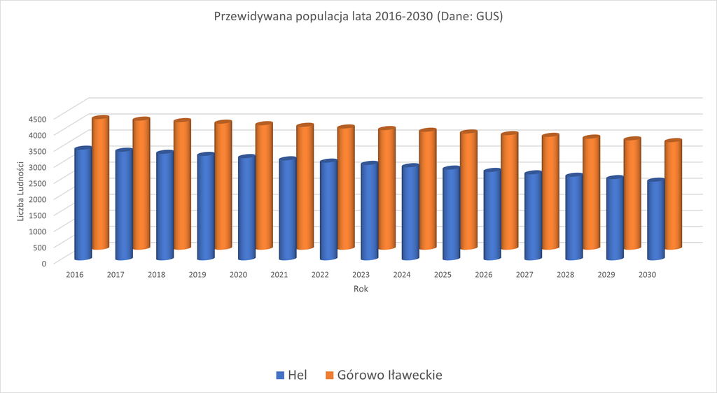

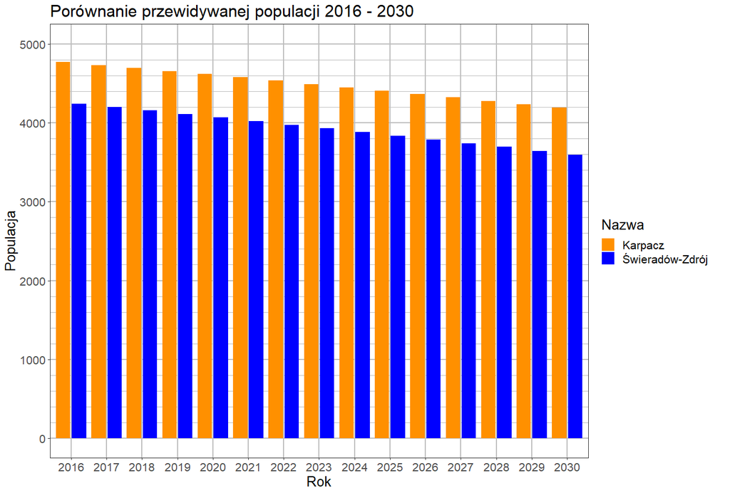

### Hipoteza

Dla wykresu 2D będzie łatwiejsze odczytywanie i porównywanie danych.

### Opis ankiety

Stworzyłem 3 krótkie zadania dla pierwszego wykresu (3D):

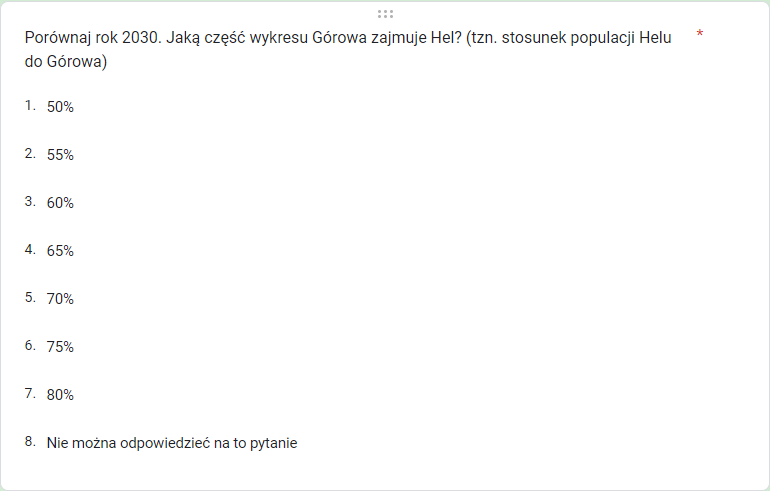

,

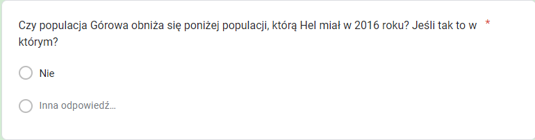

,

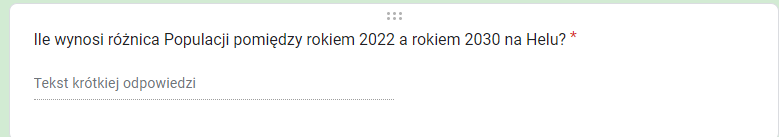

Analogiczne pytania stworzyłem dla wykresu drugiego (2D).

### Wyniki

Otrzymałem 27 odpowiedzi. Wyniki przedstawiłem na poniższych wykresach.

#### Pytanie 1.

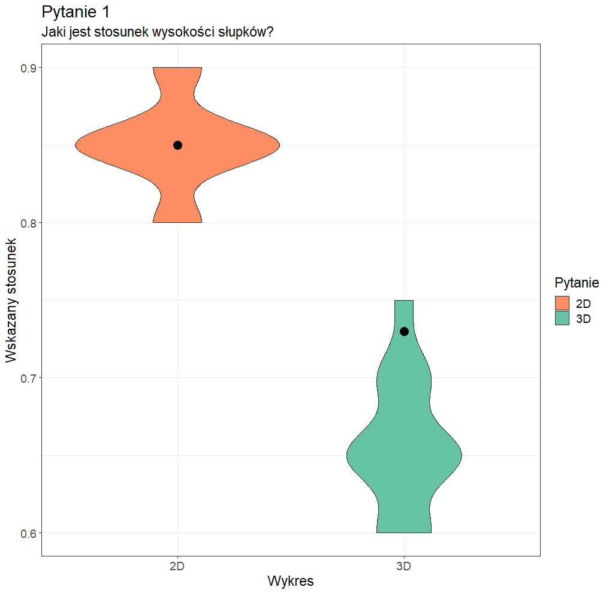

Wykres przedstawia rozkład udzielonych odpowiedzi. Czarna kropka oznacza prawidłową wartość wynoszącą 0.85 i 0.73 odpowiednio dla wykresów 2D i 3D.

Pytanie miało na celu sprawdzić, jak ankietowani radzą sobie z porównywaniem wysokości na danych wykresach. Można zauważyć na podstawie odpowiedzi, że zadanie to było o wiele łatwiejsze dla wykresu 2D - większość respondentów(64%) oszacowało dobrą wartość. Dla wykresu 3D widać, że wskazywano mniejsze wartości niż prawidłowa. 46% podało wartość 0.65 jako prawidłową wartość, a tylko 7% podało 0.75, która była najbliższa prawidłowej.

Zdecydowanie jest to skutek zastosowania perspektywy, która sprawiła, że wykresy zaczynają się na różnych wysokościach.

#### Pytanie 2.

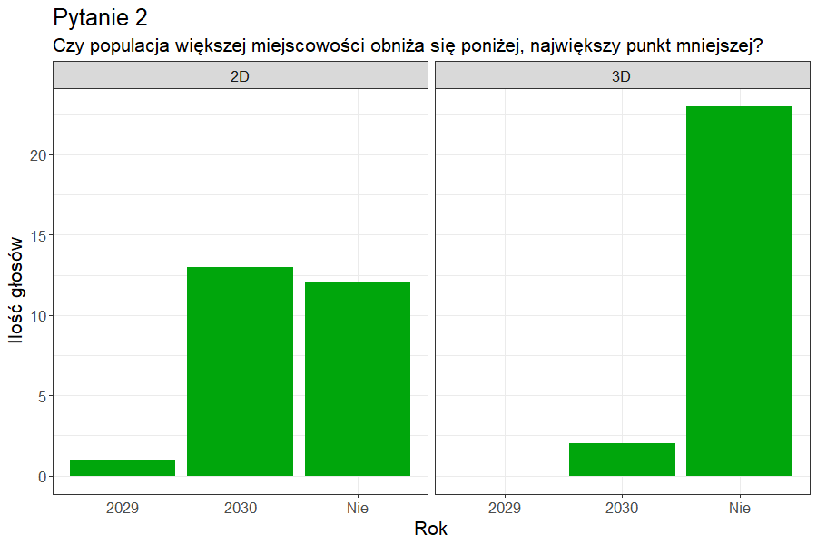

Wykres przedstawia głosy oddane na rok, w którym takie wydarzenie ma miejsce. W obu przypadkach odpowiedzią był rok 2029.

Jak widać, tylko jedna osoba dobrze odpowiedziała na pytanie przy wykresie 2D, co i tak jest o niebo lepszym wynikiem w porównaniu do wykresu 3D, gdzie spadek zauważyły tylko 2 osoby.

Problemów tutaj mogło być kilka. W wykresie 3D przede wszystkim tak jak w poprzednim zadaniu przeszkadzała perspektywa, która skutecznie uniemożliwiała dokładne i szybkie porównanie wartości. Problemem mogło być także przemieszanie dwóch miejscowości na przemian. W wykresie 2D, gdyby pokazać 2 wykresy dla poszczególnych miejscowości obok siebie, to zadanie byłoby o wiele łatwiejsze, jednak żeby nie faworyzować wykresu 2D postanowiłem tego nie robić i przedstawić dane tak jak na wykresie 3D.

#### Pytanie 3.

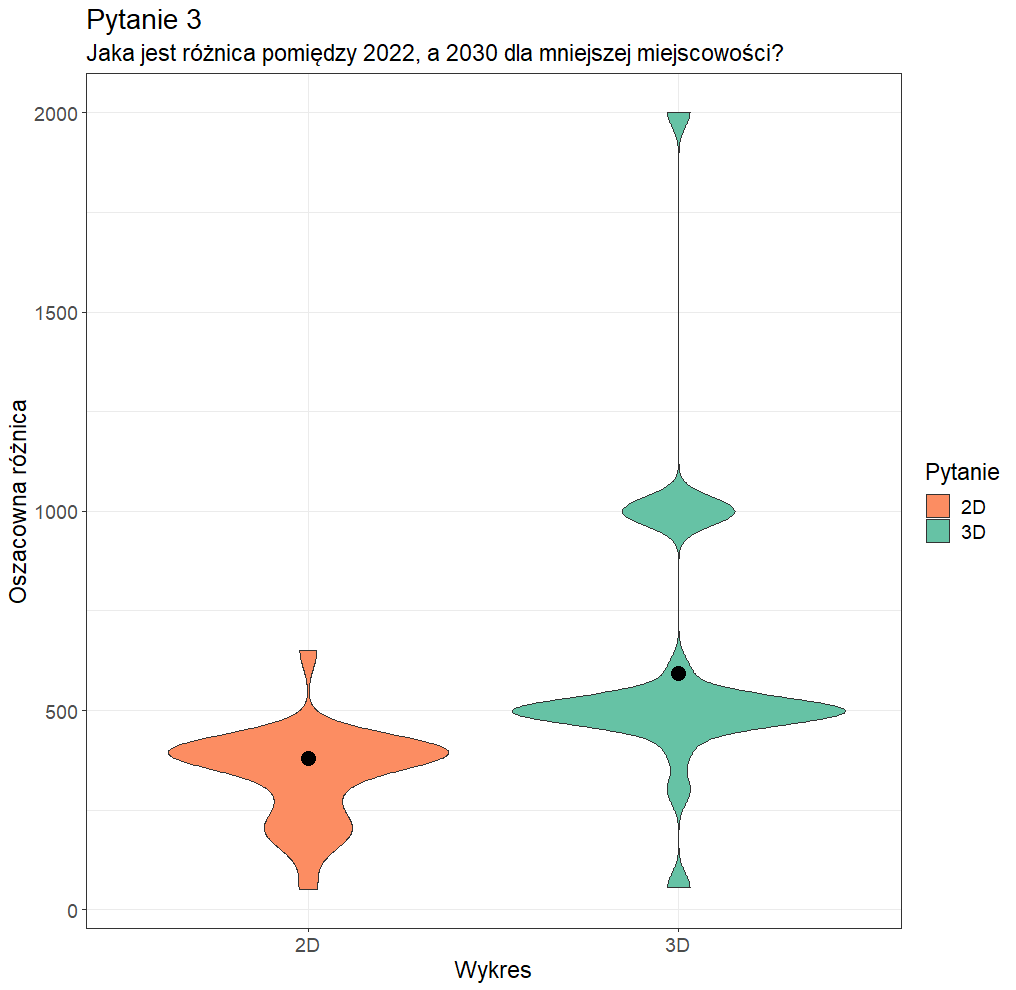

Wykres przedstawia podobny rozkład odpowiedzi, co w pytaniu pierwszym. Pominąłem 2 wyniki dla wykresu 3D, które wskazywały na różnicę wynoszącą 5000. Uznałem, że albo to błąd przy wpisywaniu albo świadoma manipulacja wynikami. Prawidłowe odpowiedzi są oznaczone kropkami i oznaczają odpowiednio 379 i 594.

Pytanie miało na celu sprawdzić sprawność w szacowaniu wyników.

Z wykresu można odczytać, że znowu dla wykresu 2D wyniki były lepsze, chociaż nie dominowały tak bardzo jak w poprzednich zadaniach. Na wykresie 3D, tak jak w pierwszym zadaniu, widzimy zaniżone wyniki. W przypadku wykresu 2D większość osób odpowiedziała 400, ale 2 osoby z dużą dokładnością dobrze oszacowały wartość 380. Przy wykresie 3D ciężko było oszacować dokładną wartość, więc większość osób podawała wartość 500 - równa podziałom osi Y. Tylko jedna osoba podała w tym przypadku wartość 600.

### Podsumowanie

Wyniki eksperymentu potwierdzają tezę, że “efektywniej” korzysta się z wykresu, który nie ma perspektywy. Respondenci również to zauważyli i podzielili się swoją opinią na ten temat:

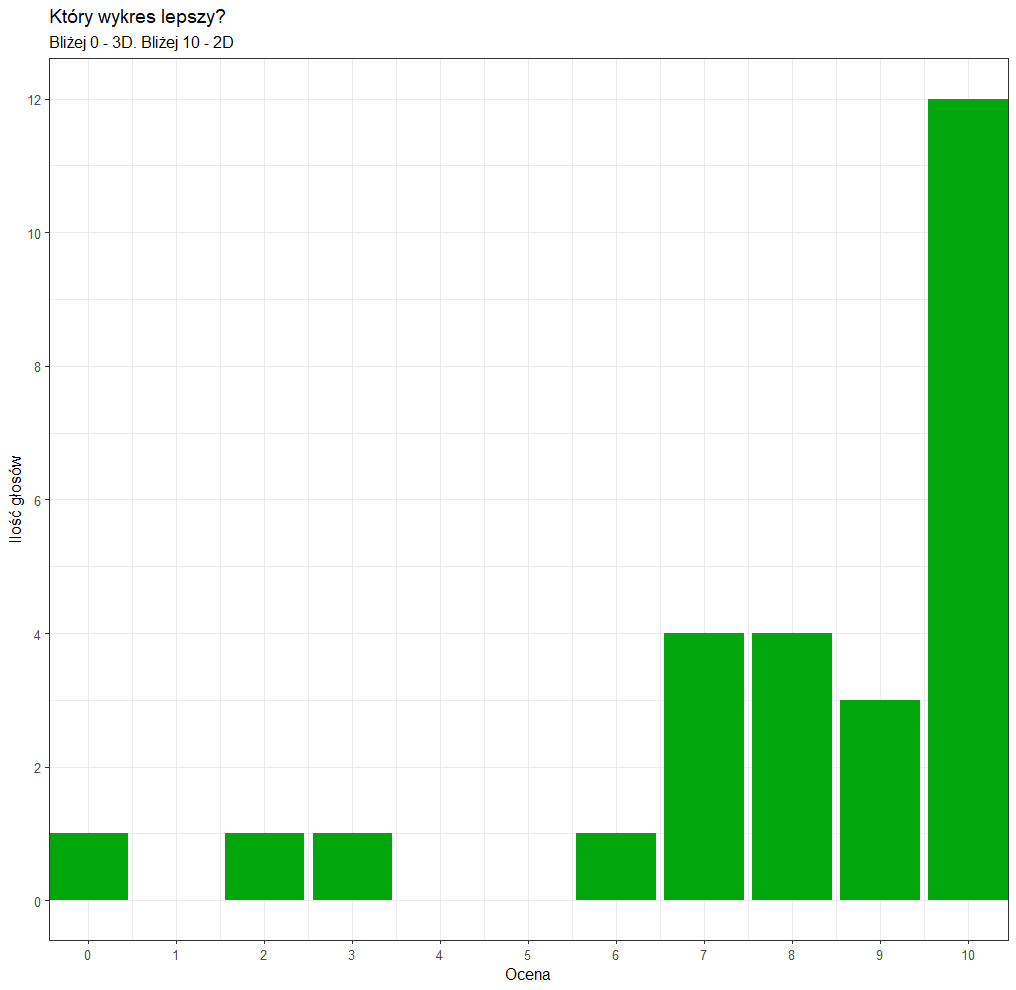